# **DS 220 Project 2**

*Data Analysis with Python Pandas (Individual) - Joshua Chang, jvc6690@psu.edu*

## **Understanding the Dataset**

The dataset we will be working on is taken from Kaggle.com, named *"World Happiness Report."* This is one of the most popular datasets in Kaggle for its good usage. This dataset contains 155 to 158 countries' happiness rank and scores, with numeric data on family, health, freedom, and more. In this project, we will analyze the *World Happiness Report (WHR)* for the year of 2015, 2016, 2017, 2018, and 2019, to get the answers for the following points and plot the results:

1. How has the happiness ranking of the United States changed from 2015 to 2019?
2. How have the 10 happiest countries changed over from 2015 to 2019?
3. How have the 10 unhappiest countries changed over from 2015 to 2019?
4. Is there any correlation between happiness levels and Gross Domestic Product (GDP) per capita?
5. Is there any correlation between happiness levels and life expectancy?
6. Which factors have the strongest impact on happiness across different countries?

## **Data Preparation & Cleaning**

### **1. Importing the dataset and python libraries**

Before we start anything, we must import the dataset into our Jupyter Notebook file. Also, to perform data analysis on the dataset, we need `pandas`, `NumPy`, and `Matplotlib`. We will import all of these now, so that we can use these throughout this project.

```python
import pandas as pd
import numpy as np
import matplotlib.pyplot as plt

data_2015 = pd.read_csv("./data/2015.csv")
data_2016 = pd.read_csv("./data/2016.csv")
data_2017 = pd.read_csv("./data/2017.csv")
data_2018 = pd.read_csv("./data/2018.csv")
data_2019 = pd.read_csv("./data/2019.csv")
```

### **2. Exploring, selecting, cleaning, and preparing the data**

Now that we imported the dataset and python libraries, let's see what we have as a column values for each dataset.

#### **2-a. Checking & renaming columns**

We can use `DATANAME.columns` to get all columns from the dataframe data. Let us proceed with all of the dataframes that we have. From the results, we can see that the name is not consistent throughout all the DataFrames. We can rename them so that they are code-friendly, and to have same names. From the results, we will see that the name is not consistent throughout all the DataFrames. We can rename them so that they are code-friendly, and to have same names going through all of them.

```python
# Checking columns in 2015.csv
data_2015.columns
```

```
Index(['Country', 'Region', 'Happiness Rank', 'Happiness Score',
       'Standard Error', 'Economy (GDP per Capita)', 'Family',
       'Health (Life Expectancy)', 'Freedom', 'Trust (Government Corruption)',
       'Generosity', 'Dystopia Residual'],
      dtype='object')
```

```python
# Renaming columns in 2015.csv
data_2015.columns = ['country', 'region', 'happiness_rank', 'happiness_score',
                     'std_error', 'economy', 'family',
                     'life_expectancy', 'freedom', 'government_corruption',
                     'generosity', 'dystopia_residual']
```

```python
# Checking changed names for columns in 2015.csv
data_2015.columns
```

```
Index(['country', 'region', 'happiness_rank', 'happiness_score', 'std_error',
       'economy', 'family', 'life_expectancy', 'freedom',
       'government_corruption', 'generosity', 'dystopia_residual'],
      dtype='object')
```

```python
# Checking columns in 2016.csv
data_2016.columns
```

```
Index(['Country', 'Region', 'Happiness Rank', 'Happiness Score',
       'Lower Confidence Interval', 'Upper Confidence Interval',
       'Economy (GDP per Capita)', 'Family', 'Health (Life Expectancy)',
       'Freedom', 'Trust (Government Corruption)', 'Generosity',
       'Dystopia Residual'],
      dtype='object')
```

```python
# Renaming columns in 2016.csv
data_2016.columns = ['country', 'region', 'happiness_rank', 'happiness_score',
                     'lower_confidence_interval', 'upper_confidence_interval',
                     'economy', 'family', 'life_expectancy',
                     'freedom', 'government_corruption', 'generosity',
                     'dystopia_residual']
```

```python
# Checking changed names for columns in 2016.csv
data_2016.columns
```

```
Index(['country', 'region', 'happiness_rank', 'happiness_score',
       'lower_confidence_interval', 'upper_confidence_interval', 'economy',
       'family', 'life_expectancy', 'freedom', 'government_corruption',
       'generosity', 'dystopia_residual'],
      dtype='object')
```

```python
# Checking columns in 2017.csv
data_2017.columns
```

```
Index(['Country', 'Happiness.Rank', 'Happiness.Score', 'Whisker.high',
       'Whisker.low', 'Economy..GDP.per.Capita.', 'Family',
       'Health..Life.Expectancy.', 'Freedom', 'Generosity',
       'Trust..Government.Corruption.', 'Dystopia.Residual'],
      dtype='object')
```

```python
# Renaming columns for 2017.csv
data_2017.columns = ['country', 'happiness_rank', 'happiness_score','whisker_high',
                     'whisker_low', 'economy', 'family',
                     'life_expectancy', 'freedom', 'generosity',
                     'government_corruption', 'dystopia_residual']
```

```python
# Checking changed names for columns in 2017.csv
data_2017.columns
```

```
Index(['country', 'happiness_rank', 'happiness_score', 'whisker_high',
       'whisker_low', 'economy', 'family', 'life_expectancy', 'freedom',
       'generosity', 'government_corruption', 'dystopia_residual'],
      dtype='object')
```

```python
# Checking columns in 2018.csv
data_2018.columns
```

```
Index(['Overall rank', 'Country or region', 'Score', 'GDP per capita',
       'Social support', 'Healthy life expectancy',
       'Freedom to make life choices', 'Generosity',
       'Perceptions of corruption'],
      dtype='object')
```

```python
# Renaming columns for 2018.csv
data_2018.columns = ['happiness_rank', 'country', 'happiness_score','economy',
                     'family', 'life_expectancy',
                     'freedom', 'generosity',
                     'government_corruption']
```

```python
# Checking changed names for columns in 2018.csv
data_2018.columns
```

```
Index(['happiness_rank', 'country', 'happiness_score', 'economy', 'family',
       'life_expectancy', 'freedom', 'generosity', 'government_corruption'],
      dtype='object')
```

```python
# Checking columns in 2019.csv
data_2019.columns
```

```
Index(['Overall rank', 'Country or region', 'Score', 'GDP per capita',
       'Social support', 'Healthy life expectancy',
       'Freedom to make life choices', 'Generosity',
       'Perceptions of corruption'],
      dtype='object')
```

```python
# Renaming columns for 2018.csv
data_2019.columns = ['happiness_rank', 'country', 'happiness_score','economy',
                     'family', 'life_expectancy',
                     'freedom', 'generosity',
                     'government_corruption']
```

```python
# Checking changed names for columns in 2019.csv
data_2019.columns
```

```
Index(['happiness_rank', 'country', 'happiness_score', 'economy', 'family',
       'life_expectancy', 'freedom', 'generosity', 'government_corruption'],
      dtype='object')
```

#### **2-b. Displaying top 5 rows**

We can use `DATANAME.head()` to get top 5 rows from the dataframe data. Let us proceed with all of the dataframes that we have.

```python
data_2015.head()
```

|  | country | region | happiness_rank | happiness_score | std_error | economy | family | life_expectancy | freedom | government_corruption | generosity | dystopia_residual |
| --- | --- | --- | --- | --- | --- | --- | --- | --- | --- | --- | --- | --- |
| 0 | Switzerland | Western Europe | 1 | 7.587 | 0.03411 | 1.39651 | 1.34951 | 0.94143 | 0.66557 | 0.41978 | 0.29678 | 2.51738 |
| 1 | Iceland | Western Europe | 2 | 7.561 | 0.04884 | 1.30232 | 1.40223 | 0.94784 | 0.62877 | 0.14145 | 0.43630 | 2.70201 |
| 2 | Denmark | Western Europe | 3 | 7.527 | 0.03328 | 1.32548 | 1.36058 | 0.87464 | 0.64938 | 0.48357 | 0.34139 | 2.49204 |
| 3 | Norway | Western Europe | 4 | 7.522 | 0.03880 | 1.45900 | 1.33095 | 0.88521 | 0.66973 | 0.36503 | 0.34699 | 2.46531 |
| 4 | Canada | North America | 5 | 7.427 | 0.03553 | 1.32629 | 1.32261 | 0.90563 | 0.63297 | 0.32957 | 0.45811 | 2.45176 |

```python
data_2016.head()
```

|  | country | region | happiness_rank | happiness_score | lower_confidence_interval | upper_confidence_interval | economy | family | life_expectancy | freedom | government_corruption | generosity | dystopia_residual |
| --- | --- | --- | --- | --- | --- | --- | --- | --- | --- | --- | --- | --- | --- |
| 0 | Denmark | Western Europe | 1 | 7.526 | 7.460 | 7.592 | 1.44178 | 1.16374 | 0.79504 | 0.57941 | 0.44453 | 0.36171 | 2.73939 |
| 1 | Switzerland | Western Europe | 2 | 7.509 | 7.428 | 7.590 | 1.52733 | 1.14524 | 0.86303 | 0.58557 | 0.41203 | 0.28083 | 2.69463 |
| 2 | Iceland | Western Europe | 3 | 7.501 | 7.333 | 7.669 | 1.42666 | 1.18326 | 0.86733 | 0.56624 | 0.14975 | 0.47678 | 2.83137 |
| 3 | Norway | Western Europe | 4 | 7.498 | 7.421 | 7.575 | 1.57744 | 1.12690 | 0.79579 | 0.59609 | 0.35776 | 0.37895 | 2.66465 |
| 4 | Finland | Western Europe | 5 | 7.413 | 7.351 | 7.475 | 1.40598 | 1.13464 | 0.81091 | 0.57104 | 0.41004 | 0.25492 | 2.82596 |

```python
data_2017.head()
```

|  | country | happiness_rank | happiness_score | whisker_high | whisker_low | economy | family | life_expectancy | freedom | generosity | government_corruption | dystopia_residual |
| --- | --- | --- | --- | --- | --- | --- | --- | --- | --- | --- | --- | --- |
| 0 | Norway | 1 | 7.537 | 7.594445 | 7.479556 | 1.616463 | 1.533524 | 0.796667 | 0.635423 | 0.362012 | 0.315964 | 2.277027 |
| 1 | Denmark | 2 | 7.522 | 7.581728 | 7.462272 | 1.482383 | 1.551122 | 0.792566 | 0.626007 | 0.355280 | 0.400770 | 2.313707 |
| 2 | Iceland | 3 | 7.504 | 7.622030 | 7.385970 | 1.480633 | 1.610574 | 0.833552 | 0.627163 | 0.475540 | 0.153527 | 2.322715 |
| 3 | Switzerland | 4 | 7.494 | 7.561772 | 7.426227 | 1.564980 | 1.516912 | 0.858131 | 0.620071 | 0.290549 | 0.367007 | 2.276716 |
| 4 | Finland | 5 | 7.469 | 7.527542 | 7.410458 | 1.443572 | 1.540247 | 0.809158 | 0.617951 | 0.245483 | 0.382612 | 2.430182 |

```python
data_2018.head()
```

|  | happiness_rank | country | happiness_score | economy | family | life_expectancy | freedom | generosity | government_corruption |
| --- | --- | --- | --- | --- | --- | --- | --- | --- | --- |
| 0 | 1 | Finland | 7.632 | 1.305 | 1.592 | 0.874 | 0.681 | 0.202 | 0.393 |
| 1 | 2 | Norway | 7.594 | 1.456 | 1.582 | 0.861 | 0.686 | 0.286 | 0.340 |
| 2 | 3 | Denmark | 7.555 | 1.351 | 1.590 | 0.868 | 0.683 | 0.284 | 0.408 |
| 3 | 4 | Iceland | 7.495 | 1.343 | 1.644 | 0.914 | 0.677 | 0.353 | 0.138 |
| 4 | 5 | Switzerland | 7.487 | 1.420 | 1.549 | 0.927 | 0.660 | 0.256 | 0.357 |

```python
data_2019.head()
```

|  | happiness_rank | country | happiness_score | economy | family | life_expectancy | freedom | generosity | government_corruption |
| --- | --- | --- | --- | --- | --- | --- | --- | --- | --- |
| 0 | 1 | Finland | 7.769 | 1.340 | 1.587 | 0.986 | 0.596 | 0.153 | 0.393 |
| 1 | 2 | Denmark | 7.600 | 1.383 | 1.573 | 0.996 | 0.592 | 0.252 | 0.410 |
| 2 | 3 | Norway | 7.554 | 1.488 | 1.582 | 1.028 | 0.603 | 0.271 | 0.341 |
| 3 | 4 | Iceland | 7.494 | 1.380 | 1.624 | 1.026 | 0.591 | 0.354 | 0.118 |
| 4 | 5 | Netherlands | 7.488 | 1.396 | 1.522 | 0.999 | 0.557 | 0.322 | 0.298 |

#### **2-c. Displaying last 5 rows**

We can use `DATANAME.tail()` to get last 5 rows from the dataframe data. Let us proceed with all of the dataframes that we have.

```python
data_2015.tail()
```

|  | country | region | happiness_rank | happiness_score | std_error | economy | family | life_expectancy | freedom | government_corruption | generosity | dystopia_residual |
| --- | --- | --- | --- | --- | --- | --- | --- | --- | --- | --- | --- | --- |
| 153 | Rwanda | Sub-Saharan Africa | 154 | 3.465 | 0.03464 | 0.22208 | 0.77370 | 0.42864 | 0.59201 | 0.55191 | 0.22628 | 0.67042 |
| 154 | Benin | Sub-Saharan Africa | 155 | 3.340 | 0.03656 | 0.28665 | 0.35386 | 0.31910 | 0.48450 | 0.08010 | 0.18260 | 1.63328 |
| 155 | Syria | Middle East and Northern Africa | 156 | 3.006 | 0.05015 | 0.66320 | 0.47489 | 0.72193 | 0.15684 | 0.18906 | 0.47179 | 0.32858 |
| 156 | Burundi | Sub-Saharan Africa | 157 | 2.905 | 0.08658 | 0.01530 | 0.41587 | 0.22396 | 0.11850 | 0.10062 | 0.19727 | 1.83302 |
| 157 | Togo | Sub-Saharan Africa | 158 | 2.839 | 0.06727 | 0.20868 | 0.13995 | 0.28443 | 0.36453 | 0.10731 | 0.16681 | 1.56726 |

```python
data_2016.tail()
```

|  | country | region | happiness_rank | happiness_score | lower_confidence_interval | upper_confidence_interval | economy | family | life_expectancy | freedom | government_corruption | generosity | dystopia_residual |
| --- | --- | --- | --- | --- | --- | --- | --- | --- | --- | --- | --- | --- | --- |
| 152 | Benin | Sub-Saharan Africa | 153 | 3.484 | 3.404 | 3.564 | 0.39499 | 0.10419 | 0.21028 | 0.39747 | 0.06681 | 0.20180 | 2.10812 |
| 153 | Afghanistan | Southern Asia | 154 | 3.360 | 3.288 | 3.432 | 0.38227 | 0.11037 | 0.17344 | 0.16430 | 0.07112 | 0.31268 | 2.14558 |
| 154 | Togo | Sub-Saharan Africa | 155 | 3.303 | 3.192 | 3.414 | 0.28123 | 0.00000 | 0.24811 | 0.34678 | 0.11587 | 0.17517 | 2.13540 |
| 155 | Syria | Middle East and Northern Africa | 156 | 3.069 | 2.936 | 3.202 | 0.74719 | 0.14866 | 0.62994 | 0.06912 | 0.17233 | 0.48397 | 0.81789 |
| 156 | Burundi | Sub-Saharan Africa | 157 | 2.905 | 2.732 | 3.078 | 0.06831 | 0.23442 | 0.15747 | 0.04320 | 0.09419 | 0.20290 | 2.10404 |

```python
data_2017.tail()
```

|  | country | happiness_rank | happiness_score | whisker_high | whisker_low | economy | family | life_expectancy | freedom | generosity | government_corruption | dystopia_residual |
| --- | --- | --- | --- | --- | --- | --- | --- | --- | --- | --- | --- | --- |
| 150 | Rwanda | 151 | 3.471 | 3.543030 | 3.398970 | 0.368746 | 0.945707 | 0.326425 | 0.581844 | 0.252756 | 0.455220 | 0.540061 |
| 151 | Syria | 152 | 3.462 | 3.663669 | 3.260331 | 0.777153 | 0.396103 | 0.500533 | 0.081539 | 0.493664 | 0.151347 | 1.061574 |
| 152 | Tanzania | 153 | 3.349 | 3.461430 | 3.236570 | 0.511136 | 1.041990 | 0.364509 | 0.390018 | 0.354256 | 0.066035 | 0.621130 |
| 153 | Burundi | 154 | 2.905 | 3.074690 | 2.735310 | 0.091623 | 0.629794 | 0.151611 | 0.059901 | 0.204435 | 0.084148 | 1.683024 |
| 154 | Central African Republic | 155 | 2.693 | 2.864884 | 2.521116 | 0.000000 | 0.000000 | 0.018773 | 0.270842 | 0.280876 | 0.056565 | 2.066005 |

```python
data_2018.tail()
```

|  | happiness_rank | country | happiness_score | economy | family | life_expectancy | freedom | generosity | government_corruption |
| --- | --- | --- | --- | --- | --- | --- | --- | --- | --- |
| 151 | 152 | Yemen | 3.355 | 0.442 | 1.073 | 0.343 | 0.244 | 0.083 | 0.064 |
| 152 | 153 | Tanzania | 3.303 | 0.455 | 0.991 | 0.381 | 0.481 | 0.270 | 0.097 |
| 153 | 154 | South Sudan | 3.254 | 0.337 | 0.608 | 0.177 | 0.112 | 0.224 | 0.106 |
| 154 | 155 | Central African Republic | 3.083 | 0.024 | 0.000 | 0.010 | 0.305 | 0.218 | 0.038 |
| 155 | 156 | Burundi | 2.905 | 0.091 | 0.627 | 0.145 | 0.065 | 0.149 | 0.076 |

```python
data_2019.tail()
```

|  | happiness_rank | country | happiness_score | economy | family | life_expectancy | freedom | generosity | government_corruption |
| --- | --- | --- | --- | --- | --- | --- | --- | --- | --- |
| 151 | 152 | Rwanda | 3.334 | 0.359 | 0.711 | 0.614 | 0.555 | 0.217 | 0.411 |
| 152 | 153 | Tanzania | 3.231 | 0.476 | 0.885 | 0.499 | 0.417 | 0.276 | 0.147 |
| 153 | 154 | Afghanistan | 3.203 | 0.350 | 0.517 | 0.361 | 0.000 | 0.158 | 0.025 |
| 154 | 155 | Central African Republic | 3.083 | 0.026 | 0.000 | 0.105 | 0.225 | 0.235 | 0.035 |
| 155 | 156 | South Sudan | 2.853 | 0.306 | 0.575 | 0.295 | 0.010 | 0.202 | 0.091 |

#### **2-d. Displaying shpaes**

We can use `DATANAME.shape` to see how many rows and columns that we have from the each dataframe data. Let us proceed with all of the dataframes that we have.

```python
data_2015.shape
```

```
(158, 12)
```

```python
data_2016.shape
```

```
(157, 13)
```

```python
data_2017.shape
```

```
(155, 12)
```

```python
data_2018.shape
```

```
(156, 9)
```

```python
data_2019.shape
```

```
(156, 9)
```

#### **2-e. Selecting the subset of data from the dataset**

From 2-a, we see that there is still some inconstencies after changing the name of the columns. Now the name of the coulmns are all same but since WHA is taken from over the years, there are some fields that is in `data_2015`, `data_2016`, `data_2017` but not in `data_2018` and `data_2019`. Since we cannot create data, let us leave some columns that does not match when we are selecting the subset. The left-out coulmns will mainly be something related to `std_error` or `dystopia_residual`.

We can use `DATANAME.iloc[:, [c1, c2, ..., cn]]` where `cn` is a column index for the columns.

Here, I tried to merge all of our datasets into one dataset, which was getting too complicated to understand the table and confusing codes. Therefore, we are keeping as 5 databases.

```python
'''
Selecting subset of data only for 'country', 'happiness_rank', 'happiness_score',
                                  'economy', 'family', 'life_expectancy',
                                  'freedom', 'government_corruption', 'generosity'

We are making these at the same order too, here.
'''

sub_data_2015 = data_2015.iloc[:,[0, 2, 3, 5, 6, 7, 8, 9 , 10]]
sub_data_2016 = data_2016.iloc[:,[0, 2, 3, 6, 7, 8, 9, 10, 11]]
sub_data_2017 = data_2017.iloc[:,[0, 1, 2, 5, 6, 7, 8, 10, 9 ]]
sub_data_2018 = data_2018.iloc[:,[1, 0, 2, 3, 4, 5, 6, 8 , 7 ]]
sub_data_2019 = data_2019.iloc[:,[1, 0, 2, 3, 4, 5, 6, 8 , 7 ]]
```

```python
# Double-Checking if subsets are selected right for data_2015
sub_data_2015.columns
```

```
Index(['country', 'happiness_rank', 'happiness_score', 'economy', 'family',
       'life_expectancy', 'freedom', 'government_corruption', 'generosity'],
      dtype='object')
```

```python
# Double-Checking if subsets are selected right for data_2016
sub_data_2016.columns
```

```
Index(['country', 'happiness_rank', 'happiness_score', 'economy', 'family',
       'life_expectancy', 'freedom', 'government_corruption', 'generosity'],
      dtype='object')
```

```python
# Double-Checking if subsets are selected right for data_2017
sub_data_2017.columns
```

```
Index(['country', 'happiness_rank', 'happiness_score', 'economy', 'family',
       'life_expectancy', 'freedom', 'government_corruption', 'generosity'],
      dtype='object')
```

```python
# Double-Checking if subsets are selected right for data_2018
sub_data_2018.columns
```

```
Index(['country', 'happiness_rank', 'happiness_score', 'economy', 'family',
       'life_expectancy', 'freedom', 'government_corruption', 'generosity'],
      dtype='object')
```

```python
# Double-Checking if subsets are selected right for data_2019
sub_data_2019.columns
```

```
Index(['country', 'happiness_rank', 'happiness_score', 'economy', 'family',
       'life_expectancy', 'freedom', 'government_corruption', 'generosity'],
      dtype='object')
```

#### **2-d. Checking for Null values**

Let us check if there is any Null values in this arrays, by using `DATANAME.isnull()` and `sum()` function.

```python
sub_data_2015.isnull().sum()
```

```
country                  0
happiness_rank           0
happiness_score          0
economy                  0
family                   0
life_expectancy          0
freedom                  0
government_corruption    0
generosity               0
dtype: int64
```

```python
sub_data_2016.isnull().sum()
```

```
country                  0
happiness_rank           0
happiness_score          0
economy                  0
family                   0
life_expectancy          0
freedom                  0
government_corruption    0
generosity               0
dtype: int64
```

```python
sub_data_2017.isnull().sum()
```

```
country                  0
happiness_rank           0
happiness_score          0
economy                  0
family                   0
life_expectancy          0
freedom                  0
government_corruption    0
generosity               0
dtype: int64
```

```python
sub_data_2018.isnull().sum()
```

```
country                  0
happiness_rank           0
happiness_score          0
economy                  0
family                   0
life_expectancy          0
freedom                  0
government_corruption    1
generosity               0
dtype: int64
```

```python
sub_data_2019.isnull().sum()
```

```
country                  0
happiness_rank           0
happiness_score          0
economy                  0
family                   0
life_expectancy          0
freedom                  0
government_corruption    0
generosity               0
dtype: int64
```

#### **2-f. Checking for duplicates**

Let us check if there is any duplicated values in this arrays, by using `DATANAME.duplicated()` and `sum()` function.

```python
sub_data_2015.duplicated().sum()
```

```
0
```

```python
sub_data_2016.duplicated().sum()
```

```
0
```

```python
sub_data_2017.duplicated().sum()
```

```
0
```

```python
sub_data_2018.duplicated().sum()
```

```
0
```

```python
sub_data_2019.duplicated().sum()
```

```
0
```

As we can see, there is no duplicated values in all of our 5 datasets.

#### **2-g. Checking for datatypes**

Let us check datatypes in this arrays, by using `DATANAME.dtypes` function.

```python
sub_data_2015.dtypes
```

```
country                   object
happiness_rank             int64
happiness_score          float64
economy                  float64
family                   float64
life_expectancy          float64
freedom                  float64
government_corruption    float64
generosity               float64
dtype: object
```

```python
sub_data_2016.dtypes
```

```
country                   object
happiness_rank             int64
happiness_score          float64
economy                  float64
family                   float64
life_expectancy          float64
freedom                  float64
government_corruption    float64
generosity               float64
dtype: object
```

```python
sub_data_2017.dtypes
```

```
country                   object
happiness_rank             int64
happiness_score          float64
economy                  float64
family                   float64
life_expectancy          float64
freedom                  float64
government_corruption    float64
generosity               float64
dtype: object
```

```python
sub_data_2018.dtypes
```

```
country                   object
happiness_rank             int64
happiness_score          float64
economy                  float64
family                   float64
life_expectancy          float64
freedom                  float64
government_corruption    float64
generosity               float64
dtype: object
```

```python
sub_data_2019.dtypes
```

```
country                   object
happiness_rank             int64
happiness_score          float64
economy                  float64
family                   float64
life_expectancy          float64
freedom                  float64
government_corruption    float64
generosity               float64
dtype: object
```

We have chekced throughout all of the databases and coulmns, have consistency on their datatypes.

#### **2-h. Checking for datatypes**

Let us sort these dataframes on the column `happiness_rank`, by using `DATANAME.sort_values('COLUMNNAME')`.

```python
sub_data_2015.sort_values('happiness_rank')
```

|  | country | happiness_rank | happiness_score | economy | family | life_expectancy | freedom | government_corruption | generosity |
| --- | --- | --- | --- | --- | --- | --- | --- | --- | --- |
| 0 | Switzerland | 1 | 7.587 | 1.39651 | 1.34951 | 0.94143 | 0.66557 | 0.41978 | 0.29678 |
| 1 | Iceland | 2 | 7.561 | 1.30232 | 1.40223 | 0.94784 | 0.62877 | 0.14145 | 0.43630 |
| 2 | Denmark | 3 | 7.527 | 1.32548 | 1.36058 | 0.87464 | 0.64938 | 0.48357 | 0.34139 |
| 3 | Norway | 4 | 7.522 | 1.45900 | 1.33095 | 0.88521 | 0.66973 | 0.36503 | 0.34699 |
| 4 | Canada | 5 | 7.427 | 1.32629 | 1.32261 | 0.90563 | 0.63297 | 0.32957 | 0.45811 |
| ... | ... | ... | ... | ... | ... | ... | ... | ... | ... |
| 153 | Rwanda | 154 | 3.465 | 0.22208 | 0.77370 | 0.42864 | 0.59201 | 0.55191 | 0.22628 |
| 154 | Benin | 155 | 3.340 | 0.28665 | 0.35386 | 0.31910 | 0.48450 | 0.08010 | 0.18260 |
| 155 | Syria | 156 | 3.006 | 0.66320 | 0.47489 | 0.72193 | 0.15684 | 0.18906 | 0.47179 |
| 156 | Burundi | 157 | 2.905 | 0.01530 | 0.41587 | 0.22396 | 0.11850 | 0.10062 | 0.19727 |
| 157 | Togo | 158 | 2.839 | 0.20868 | 0.13995 | 0.28443 | 0.36453 | 0.10731 | 0.16681 |

158 rows × 9 columns

```python
sub_data_2016.sort_values('happiness_rank')
```

|  | country | happiness_rank | happiness_score | economy | family | life_expectancy | freedom | government_corruption | generosity |
| --- | --- | --- | --- | --- | --- | --- | --- | --- | --- |
| 0 | Denmark | 1 | 7.526 | 1.44178 | 1.16374 | 0.79504 | 0.57941 | 0.44453 | 0.36171 |
| 1 | Switzerland | 2 | 7.509 | 1.52733 | 1.14524 | 0.86303 | 0.58557 | 0.41203 | 0.28083 |
| 2 | Iceland | 3 | 7.501 | 1.42666 | 1.18326 | 0.86733 | 0.56624 | 0.14975 | 0.47678 |
| 3 | Norway | 4 | 7.498 | 1.57744 | 1.12690 | 0.79579 | 0.59609 | 0.35776 | 0.37895 |
| 4 | Finland | 5 | 7.413 | 1.40598 | 1.13464 | 0.81091 | 0.57104 | 0.41004 | 0.25492 |
| ... | ... | ... | ... | ... | ... | ... | ... | ... | ... |
| 152 | Benin | 153 | 3.484 | 0.39499 | 0.10419 | 0.21028 | 0.39747 | 0.06681 | 0.20180 |
| 153 | Afghanistan | 154 | 3.360 | 0.38227 | 0.11037 | 0.17344 | 0.16430 | 0.07112 | 0.31268 |
| 154 | Togo | 155 | 3.303 | 0.28123 | 0.00000 | 0.24811 | 0.34678 | 0.11587 | 0.17517 |
| 155 | Syria | 156 | 3.069 | 0.74719 | 0.14866 | 0.62994 | 0.06912 | 0.17233 | 0.48397 |
| 156 | Burundi | 157 | 2.905 | 0.06831 | 0.23442 | 0.15747 | 0.04320 | 0.09419 | 0.20290 |

157 rows × 9 columns

```python
sub_data_2017.sort_values('happiness_rank')
```

|  | country | happiness_rank | happiness_score | economy | family | life_expectancy | freedom | government_corruption | generosity |
| --- | --- | --- | --- | --- | --- | --- | --- | --- | --- |
| 0 | Norway | 1 | 7.537 | 1.616463 | 1.533524 | 0.796667 | 0.635423 | 0.315964 | 0.362012 |
| 1 | Denmark | 2 | 7.522 | 1.482383 | 1.551122 | 0.792566 | 0.626007 | 0.400770 | 0.355280 |
| 2 | Iceland | 3 | 7.504 | 1.480633 | 1.610574 | 0.833552 | 0.627163 | 0.153527 | 0.475540 |
| 3 | Switzerland | 4 | 7.494 | 1.564980 | 1.516912 | 0.858131 | 0.620071 | 0.367007 | 0.290549 |
| 4 | Finland | 5 | 7.469 | 1.443572 | 1.540247 | 0.809158 | 0.617951 | 0.382612 | 0.245483 |
| ... | ... | ... | ... | ... | ... | ... | ... | ... | ... |
| 150 | Rwanda | 151 | 3.471 | 0.368746 | 0.945707 | 0.326425 | 0.581844 | 0.455220 | 0.252756 |
| 151 | Syria | 152 | 3.462 | 0.777153 | 0.396103 | 0.500533 | 0.081539 | 0.151347 | 0.493664 |
| 152 | Tanzania | 153 | 3.349 | 0.511136 | 1.041990 | 0.364509 | 0.390018 | 0.066035 | 0.354256 |
| 153 | Burundi | 154 | 2.905 | 0.091623 | 0.629794 | 0.151611 | 0.059901 | 0.084148 | 0.204435 |
| 154 | Central African Republic | 155 | 2.693 | 0.000000 | 0.000000 | 0.018773 | 0.270842 | 0.056565 | 0.280876 |

155 rows × 9 columns

```python
sub_data_2018.sort_values('happiness_rank')
```

|  | country | happiness_rank | happiness_score | economy | family | life_expectancy | freedom | government_corruption | generosity |
| --- | --- | --- | --- | --- | --- | --- | --- | --- | --- |
| 0 | Finland | 1 | 7.632 | 1.305 | 1.592 | 0.874 | 0.681 | 0.393 | 0.202 |
| 1 | Norway | 2 | 7.594 | 1.456 | 1.582 | 0.861 | 0.686 | 0.340 | 0.286 |
| 2 | Denmark | 3 | 7.555 | 1.351 | 1.590 | 0.868 | 0.683 | 0.408 | 0.284 |
| 3 | Iceland | 4 | 7.495 | 1.343 | 1.644 | 0.914 | 0.677 | 0.138 | 0.353 |
| 4 | Switzerland | 5 | 7.487 | 1.420 | 1.549 | 0.927 | 0.660 | 0.357 | 0.256 |
| ... | ... | ... | ... | ... | ... | ... | ... | ... | ... |
| 151 | Yemen | 152 | 3.355 | 0.442 | 1.073 | 0.343 | 0.244 | 0.064 | 0.083 |
| 152 | Tanzania | 153 | 3.303 | 0.455 | 0.991 | 0.381 | 0.481 | 0.097 | 0.270 |
| 153 | South Sudan | 154 | 3.254 | 0.337 | 0.608 | 0.177 | 0.112 | 0.106 | 0.224 |
| 154 | Central African Republic | 155 | 3.083 | 0.024 | 0.000 | 0.010 | 0.305 | 0.038 | 0.218 |
| 155 | Burundi | 156 | 2.905 | 0.091 | 0.627 | 0.145 | 0.065 | 0.076 | 0.149 |

156 rows × 9 columns

```python
sub_data_2019.sort_values('happiness_rank')
```

|  | country | happiness_rank | happiness_score | economy | family | life_expectancy | freedom | government_corruption | generosity |
| --- | --- | --- | --- | --- | --- | --- | --- | --- | --- |
| 0 | Finland | 1 | 7.769 | 1.340 | 1.587 | 0.986 | 0.596 | 0.393 | 0.153 |
| 1 | Denmark | 2 | 7.600 | 1.383 | 1.573 | 0.996 | 0.592 | 0.410 | 0.252 |
| 2 | Norway | 3 | 7.554 | 1.488 | 1.582 | 1.028 | 0.603 | 0.341 | 0.271 |
| 3 | Iceland | 4 | 7.494 | 1.380 | 1.624 | 1.026 | 0.591 | 0.118 | 0.354 |
| 4 | Netherlands | 5 | 7.488 | 1.396 | 1.522 | 0.999 | 0.557 | 0.298 | 0.322 |
| ... | ... | ... | ... | ... | ... | ... | ... | ... | ... |
| 151 | Rwanda | 152 | 3.334 | 0.359 | 0.711 | 0.614 | 0.555 | 0.411 | 0.217 |
| 152 | Tanzania | 153 | 3.231 | 0.476 | 0.885 | 0.499 | 0.417 | 0.147 | 0.276 |
| 153 | Afghanistan | 154 | 3.203 | 0.350 | 0.517 | 0.361 | 0.000 | 0.025 | 0.158 |
| 154 | Central African Republic | 155 | 3.083 | 0.026 | 0.000 | 0.105 | 0.225 | 0.035 | 0.235 |
| 155 | South Sudan | 156 | 2.853 | 0.306 | 0.575 | 0.295 | 0.010 | 0.091 | 0.202 |

156 rows × 9 columns

#### **2-i. Setting indexes for datatypes**

Let us set the index for these dataframes as `country`, by using `DATANAME.set_index('COLUMNNAME'), inplace=BOOLEAN`.

```python
sub_data_2015.set_index('country', inplace=True)
sub_data_2015
```

| country | happiness_rank | happiness_score | economy | family | life_expectancy | freedom | government_corruption | generosity |
| --- | --- | --- | --- | --- | --- | --- | --- | --- |
| Switzerland | 1 | 7.587 | 1.39651 | 1.34951 | 0.94143 | 0.66557 | 0.41978 | 0.29678 |
| Iceland | 2 | 7.561 | 1.30232 | 1.40223 | 0.94784 | 0.62877 | 0.14145 | 0.43630 |
| Denmark | 3 | 7.527 | 1.32548 | 1.36058 | 0.87464 | 0.64938 | 0.48357 | 0.34139 |
| Norway | 4 | 7.522 | 1.45900 | 1.33095 | 0.88521 | 0.66973 | 0.36503 | 0.34699 |
| Canada | 5 | 7.427 | 1.32629 | 1.32261 | 0.90563 | 0.63297 | 0.32957 | 0.45811 |
| ... | ... | ... | ... | ... | ... | ... | ... | ... |
| Rwanda | 154 | 3.465 | 0.22208 | 0.77370 | 0.42864 | 0.59201 | 0.55191 | 0.22628 |
| Benin | 155 | 3.340 | 0.28665 | 0.35386 | 0.31910 | 0.48450 | 0.08010 | 0.18260 |
| Syria | 156 | 3.006 | 0.66320 | 0.47489 | 0.72193 | 0.15684 | 0.18906 | 0.47179 |
| Burundi | 157 | 2.905 | 0.01530 | 0.41587 | 0.22396 | 0.11850 | 0.10062 | 0.19727 |
| Togo | 158 | 2.839 | 0.20868 | 0.13995 | 0.28443 | 0.36453 | 0.10731 | 0.16681 |

158 rows × 8 columns

```python
sub_data_2016.set_index('country', inplace=True)
sub_data_2016
```

| country | happiness_rank | happiness_score | economy | family | life_expectancy | freedom | government_corruption | generosity |
| --- | --- | --- | --- | --- | --- | --- | --- | --- |
| Denmark | 1 | 7.526 | 1.44178 | 1.16374 | 0.79504 | 0.57941 | 0.44453 | 0.36171 |
| Switzerland | 2 | 7.509 | 1.52733 | 1.14524 | 0.86303 | 0.58557 | 0.41203 | 0.28083 |
| Iceland | 3 | 7.501 | 1.42666 | 1.18326 | 0.86733 | 0.56624 | 0.14975 | 0.47678 |
| Norway | 4 | 7.498 | 1.57744 | 1.12690 | 0.79579 | 0.59609 | 0.35776 | 0.37895 |
| Finland | 5 | 7.413 | 1.40598 | 1.13464 | 0.81091 | 0.57104 | 0.41004 | 0.25492 |
| ... | ... | ... | ... | ... | ... | ... | ... | ... |
| Benin | 153 | 3.484 | 0.39499 | 0.10419 | 0.21028 | 0.39747 | 0.06681 | 0.20180 |
| Afghanistan | 154 | 3.360 | 0.38227 | 0.11037 | 0.17344 | 0.16430 | 0.07112 | 0.31268 |
| Togo | 155 | 3.303 | 0.28123 | 0.00000 | 0.24811 | 0.34678 | 0.11587 | 0.17517 |
| Syria | 156 | 3.069 | 0.74719 | 0.14866 | 0.62994 | 0.06912 | 0.17233 | 0.48397 |
| Burundi | 157 | 2.905 | 0.06831 | 0.23442 | 0.15747 | 0.04320 | 0.09419 | 0.20290 |

157 rows × 8 columns

```python
sub_data_2017.set_index('country', inplace=True)
sub_data_2017
```

| country | happiness_rank | happiness_score | economy | family | life_expectancy | freedom | government_corruption | generosity |
| --- | --- | --- | --- | --- | --- | --- | --- | --- |
| Norway | 1 | 7.537 | 1.616463 | 1.533524 | 0.796667 | 0.635423 | 0.315964 | 0.362012 |
| Denmark | 2 | 7.522 | 1.482383 | 1.551122 | 0.792566 | 0.626007 | 0.400770 | 0.355280 |
| Iceland | 3 | 7.504 | 1.480633 | 1.610574 | 0.833552 | 0.627163 | 0.153527 | 0.475540 |
| Switzerland | 4 | 7.494 | 1.564980 | 1.516912 | 0.858131 | 0.620071 | 0.367007 | 0.290549 |
| Finland | 5 | 7.469 | 1.443572 | 1.540247 | 0.809158 | 0.617951 | 0.382612 | 0.245483 |
| ... | ... | ... | ... | ... | ... | ... | ... | ... |
| Rwanda | 151 | 3.471 | 0.368746 | 0.945707 | 0.326425 | 0.581844 | 0.455220 | 0.252756 |
| Syria | 152 | 3.462 | 0.777153 | 0.396103 | 0.500533 | 0.081539 | 0.151347 | 0.493664 |
| Tanzania | 153 | 3.349 | 0.511136 | 1.041990 | 0.364509 | 0.390018 | 0.066035 | 0.354256 |
| Burundi | 154 | 2.905 | 0.091623 | 0.629794 | 0.151611 | 0.059901 | 0.084148 | 0.204435 |
| Central African Republic | 155 | 2.693 | 0.000000 | 0.000000 | 0.018773 | 0.270842 | 0.056565 | 0.280876 |

155 rows × 8 columns

```python
sub_data_2018.set_index('country', inplace=True)
sub_data_2018
```

| country | happiness_rank | happiness_score | economy | family | life_expectancy | freedom | government_corruption | generosity |
| --- | --- | --- | --- | --- | --- | --- | --- | --- |
| Finland | 1 | 7.632 | 1.305 | 1.592 | 0.874 | 0.681 | 0.393 | 0.202 |
| Norway | 2 | 7.594 | 1.456 | 1.582 | 0.861 | 0.686 | 0.340 | 0.286 |
| Denmark | 3 | 7.555 | 1.351 | 1.590 | 0.868 | 0.683 | 0.408 | 0.284 |
| Iceland | 4 | 7.495 | 1.343 | 1.644 | 0.914 | 0.677 | 0.138 | 0.353 |
| Switzerland | 5 | 7.487 | 1.420 | 1.549 | 0.927 | 0.660 | 0.357 | 0.256 |
| ... | ... | ... | ... | ... | ... | ... | ... | ... |
| Yemen | 152 | 3.355 | 0.442 | 1.073 | 0.343 | 0.244 | 0.064 | 0.083 |
| Tanzania | 153 | 3.303 | 0.455 | 0.991 | 0.381 | 0.481 | 0.097 | 0.270 |
| South Sudan | 154 | 3.254 | 0.337 | 0.608 | 0.177 | 0.112 | 0.106 | 0.224 |
| Central African Republic | 155 | 3.083 | 0.024 | 0.000 | 0.010 | 0.305 | 0.038 | 0.218 |
| Burundi | 156 | 2.905 | 0.091 | 0.627 | 0.145 | 0.065 | 0.076 | 0.149 |

156 rows × 8 columns

```python
sub_data_2019.set_index('country', inplace=True)
sub_data_2019
```

| country | happiness_rank | happiness_score | economy | family | life_expectancy | freedom | government_corruption | generosity |
| --- | --- | --- | --- | --- | --- | --- | --- | --- |
| Finland | 1 | 7.769 | 1.340 | 1.587 | 0.986 | 0.596 | 0.393 | 0.153 |
| Denmark | 2 | 7.600 | 1.383 | 1.573 | 0.996 | 0.592 | 0.410 | 0.252 |
| Norway | 3 | 7.554 | 1.488 | 1.582 | 1.028 | 0.603 | 0.341 | 0.271 |
| Iceland | 4 | 7.494 | 1.380 | 1.624 | 1.026 | 0.591 | 0.118 | 0.354 |
| Netherlands | 5 | 7.488 | 1.396 | 1.522 | 0.999 | 0.557 | 0.298 | 0.322 |
| ... | ... | ... | ... | ... | ... | ... | ... | ... |
| Rwanda | 152 | 3.334 | 0.359 | 0.711 | 0.614 | 0.555 | 0.411 | 0.217 |
| Tanzania | 153 | 3.231 | 0.476 | 0.885 | 0.499 | 0.417 | 0.147 | 0.276 |
| Afghanistan | 154 | 3.203 | 0.350 | 0.517 | 0.361 | 0.000 | 0.025 | 0.158 |
| Central African Republic | 155 | 3.083 | 0.026 | 0.000 | 0.105 | 0.225 | 0.035 | 0.235 |
| South Sudan | 156 | 2.853 | 0.306 | 0.575 | 0.295 | 0.010 | 0.091 | 0.202 |

156 rows × 8 columns

## **Data Analysis**

Now that we have all the datasets ready, we can start analysis tasks that we questioned at the beginning of the project, which are as following. We will go number by number.

1. How has the happiness ranking of the United States changed from 2015 to 2019?
2. How have the 10 happiest countries changed over from 2015 to 2019?
3. How have the 10 unhappiest countries changed over from 2015 to 2019?
4. Is there any correlation between happiness levels and Gross Domestic Product (GDP) per capita?
5. Is there any correlation between happiness levels and life expectancy?
6. Which factors have the strongest impact on happiness across different countries?

### **1. How has the happiness ranking of the United States changed from 2015 to 2019?**

To check this, we would have to create another table that consists `Year` and `Happiness Ranking the of United States` as the columns. We can use pandas library to create the DataFrame.

```python
q1 = pd.DataFrame([(2015, sub_data_2015.at['United States', 'happiness_rank']),
                   (2016, sub_data_2016.at['United States', 'happiness_rank']),
                   (2017, sub_data_2017.at['United States', 'happiness_rank']),
                   (2018, sub_data_2018.at['United States', 'happiness_rank']),
                   (2019, sub_data_2019.at['United States', 'happiness_rank']),],
                   columns = ('Year', 'Happiness Ranking of the United States'))
q1
```

|  | Year | Happiness Ranking of the United States |
| --- | --- | --- |
| 0 | 2015 | 15 |
| 1 | 2016 | 13 |
| 2 | 2017 | 14 |
| 3 | 2018 | 18 |
| 4 | 2019 | 19 |

Now, we can make the Year values as index of the table.

```python
q1.set_index('Year', inplace=True)
q1
```

| Year | Happiness Ranking of the United States |
| --- | --- |
| 2015 | 15 |
| 2016 | 13 |
| 2017 | 14 |
| 2018 | 18 |
| 2019 | 19 |

Now that we have a dataframe with the values that we only want, we can create the visualize this dataframe with matplotlib library. A graph of the happiness ranking of the United States from 2015 to 2019 is shown below.

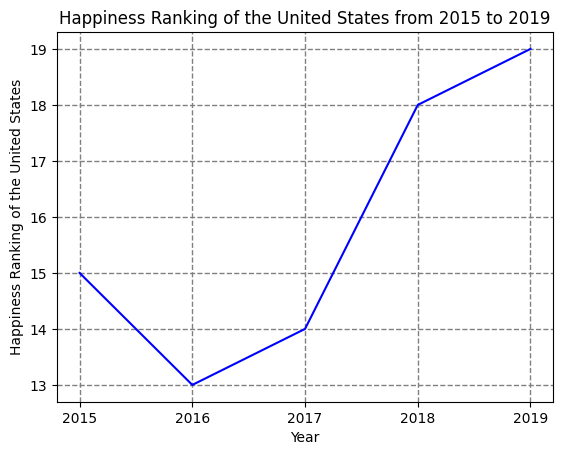

```python
plt.plot(q1, color='Blue')
plt.grid(color='gray', linestyle='--', linewidth=1)
plt.xlabel('Year')
plt.xticks([2015, 2016, 2017, 2018, 2019])
plt.ylabel('Happiness Ranking of the United States')
plt.title('Happiness Ranking of the United States from 2015 to 2019')
plt.show()
```

### **2. How have the 10 happiest countries changed over from 2015 to 2019?**

We can first make a table that contains `country` names of top 10 happiest countries, with their `happiness_score` values. Since we already sorted this subdatas in to decreasing order of `happiness_rank` earlier, we would have to take first 10 values. We will go through this process with every year, and see the change in the rankings by 5 bar graphs.

```python
top_10_2015 = sub_data_2015.iloc[:,[1]][0:10]
top_10_2015
```

| country | happiness_score |
| --- | --- |
| Switzerland | 7.587 |
| Iceland | 7.561 |
| Denmark | 7.527 |
| Norway | 7.522 |
| Canada | 7.427 |
| Finland | 7.406 |
| Netherlands | 7.378 |
| Sweden | 7.364 |
| New Zealand | 7.286 |
| Australia | 7.284 |

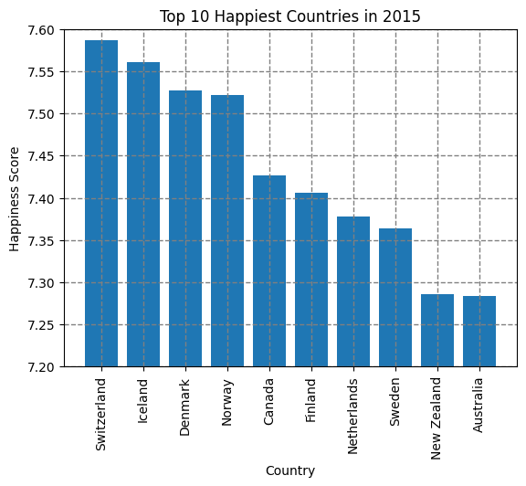

```python
x = list(top_10_2015.index)
y = top_10_2015['happiness_score']

plt.bar(x, y)
plt.grid(color='grey', linestyle='--', linewidth=1)
plt.xlabel('Country')
plt.xticks(rotation = 'vertical', fontsize=10)
plt.ylim(7.2, 7.6)
plt.ylabel('Happiness Score')
plt.title('Top 10 Happiest Countries in 2015')
plt.show()
```

```python
top_10_2016 = sub_data_2016.iloc[:,[1]][0:10]
top_10_2016
```

| country | happiness_score |
| --- | --- |
| Denmark | 7.526 |
| Switzerland | 7.509 |
| Iceland | 7.501 |
| Norway | 7.498 |
| Finland | 7.413 |
| Canada | 7.404 |
| Netherlands | 7.339 |
| New Zealand | 7.334 |
| Australia | 7.313 |
| Sweden | 7.291 |

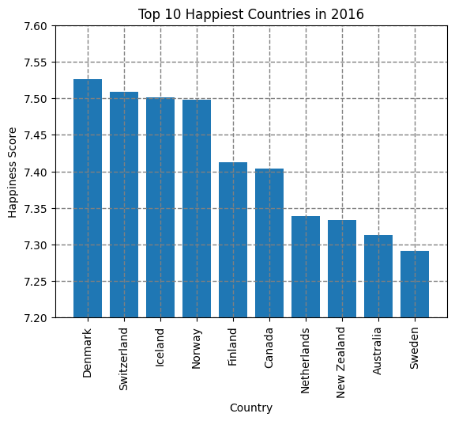

```python
x = list(top_10_2016.index)
y = top_10_2016['happiness_score']

plt.bar(x, y)
plt.grid(color='grey', linestyle='--', linewidth=1)
plt.xlabel('Country')
plt.xticks(rotation = 'vertical', fontsize=10)
plt.ylim(7.2, 7.6)
plt.ylabel('Happiness Score')
plt.title('Top 10 Happiest Countries in 2016')
plt.show()
```

```python
top_10_2017 = sub_data_2017.iloc[:,[1]][0:10]
top_10_2017
```

| country | happiness_score |
| --- | --- |
| Norway | 7.537 |
| Denmark | 7.522 |
| Iceland | 7.504 |
| Switzerland | 7.494 |
| Finland | 7.469 |
| Netherlands | 7.377 |
| Canada | 7.316 |
| New Zealand | 7.314 |
| Sweden | 7.284 |
| Australia | 7.284 |

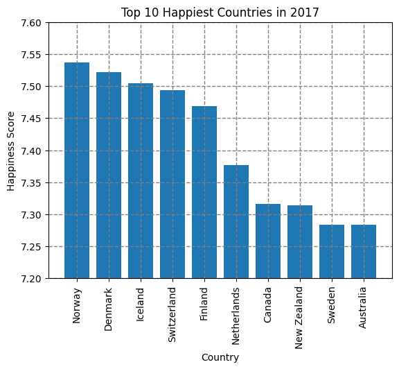

```python
x = list(top_10_2017.index)
y = top_10_2017['happiness_score']

plt.bar(x, y)
plt.grid(color='grey', linestyle='--', linewidth=1)
plt.xlabel('Country')
plt.xticks(rotation = 'vertical', fontsize=10)
plt.ylim(7.2, 7.6)
plt.ylabel('Happiness Score')
plt.title('Top 10 Happiest Countries in 2017')
plt.show()
```

```python
top_10_2018 = sub_data_2018.iloc[:,[1]][0:10]
top_10_2018
```

| country | happiness_score |
| --- | --- |
| Finland | 7.632 |
| Norway | 7.594 |
| Denmark | 7.555 |
| Iceland | 7.495 |
| Switzerland | 7.487 |
| Netherlands | 7.441 |
| Canada | 7.328 |
| New Zealand | 7.324 |
| Sweden | 7.314 |
| Australia | 7.272 |

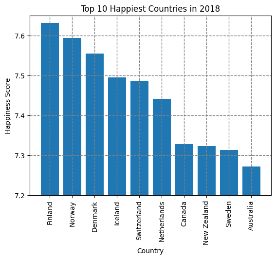

```python
x = list(top_10_2018.index)
y = top_10_2018['happiness_score']

plt.bar(x, y)
plt.grid(color='grey', linestyle='--', linewidth=1)
plt.xlabel('Country')
plt.xticks(rotation = 'vertical', fontsize=10)
plt.ylim(7.2, 7.65)
plt.ylabel('Happiness Score')
plt.title('Top 10 Happiest Countries in 2018')
plt.show()
```

```python
top_10_2019 = sub_data_2019.iloc[:,[1]][0:10]
top_10_2019
```

| country | happiness_score |
| --- | --- |
| Finland | 7.769 |
| Denmark | 7.600 |
| Norway | 7.554 |
| Iceland | 7.494 |
| Netherlands | 7.488 |
| Switzerland | 7.480 |
| Sweden | 7.343 |
| New Zealand | 7.307 |
| Canada | 7.278 |
| Austria | 7.246 |

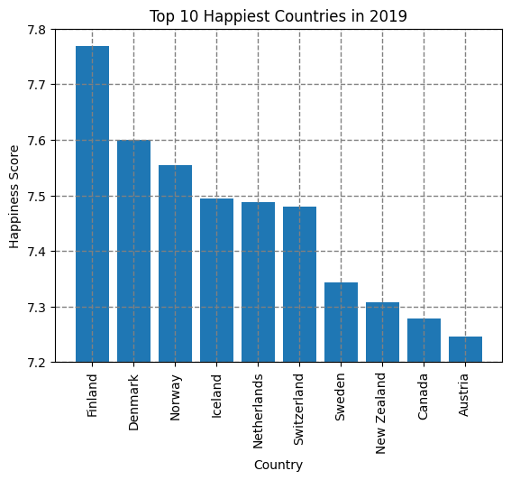

```python
x = list(top_10_2019.index)
y = top_10_2019['happiness_score']

plt.bar(x, y)
plt.grid(color='grey', linestyle='--', linewidth=1)
plt.xlabel('Country')
plt.xticks(rotation = 'vertical', fontsize=10)
plt.ylim(7.2, 7.8)
plt.ylabel('Happiness Score')
plt.title('Top 10 Happiest Countries in 2019')
plt.show()
```

### **2. How have the 10 unhappiest countries changed over from 2015 to 2019?**

We can first make a table that contains `country` names of top 10 unhappiest countries, with their `happiness_score` values. Since we already sorted this subdatas in to decreasing order of `happiness_rank` earlier, we would have to take last 10 values. We will go through this process with every year, and see the change in the rankings by 5 bar graphs.

```python
top_10_2015 = sub_data_2015.iloc[:,[1]][-10:]
top_10_2015
```

| country | happiness_score |
| --- | --- |
| Chad | 3.667 |
| Guinea | 3.656 |
| Ivory Coast | 3.655 |
| Burkina Faso | 3.587 |
| Afghanistan | 3.575 |
| Rwanda | 3.465 |
| Benin | 3.340 |
| Syria | 3.006 |
| Burundi | 2.905 |
| Togo | 2.839 |

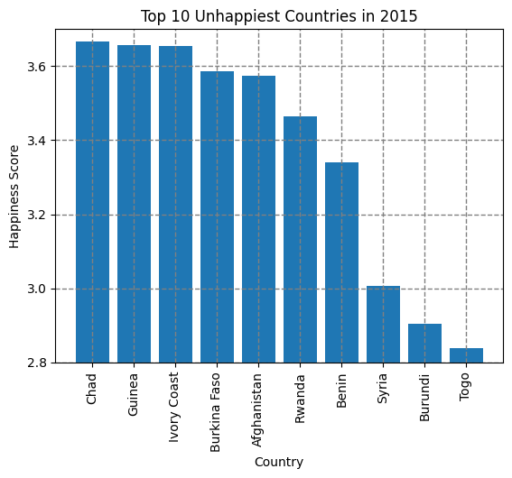

```python
x = list(top_10_2015.index)
y = top_10_2015['happiness_score']

plt.bar(x, y)
plt.grid(color='grey', linestyle='--', linewidth=1)
plt.xlabel('Country')
plt.xticks(rotation = 'vertical', fontsize=10)
plt.ylim(2.8, 3.7)
plt.ylabel('Happiness Score')
plt.title('Top 10 Unhappiest Countries in 2015')
plt.show()
```

```python
top_10_2016 = sub_data_2016.iloc[:,[1]][-10:]
top_10_2016
```

| country | happiness_score |
| --- | --- |
| Madagascar | 3.695 |
| Tanzania | 3.666 |
| Liberia | 3.622 |
| Guinea | 3.607 |
| Rwanda | 3.515 |
| Benin | 3.484 |
| Afghanistan | 3.360 |
| Togo | 3.303 |
| Syria | 3.069 |
| Burundi | 2.905 |

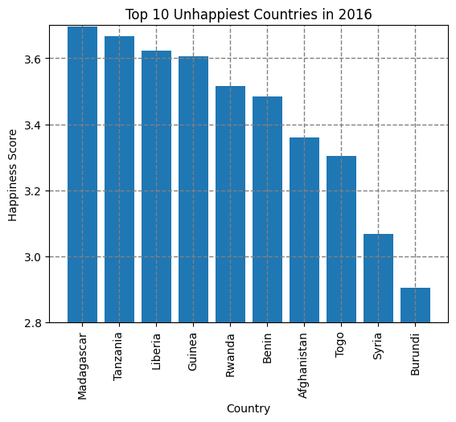

```python
x = list(top_10_2016.index)
y = top_10_2016['happiness_score']

plt.bar(x, y)
plt.grid(color='grey', linestyle='--', linewidth=1)
plt.xlabel('Country')
plt.xticks(rotation = 'vertical', fontsize=10)
plt.ylim(2.8, 3.7)
plt.ylabel('Happiness Score')
plt.title('Top 10 Unhappiest Countries in 2016')
plt.show()
```

```python
top_10_2017 = sub_data_2017.iloc[:,[1]][-10:]
top_10_2017
```

| country | happiness_score |
| --- | --- |
| Yemen | 3.593 |
| South Sudan | 3.591 |
| Liberia | 3.533 |
| Guinea | 3.507 |
| Togo | 3.495 |
| Rwanda | 3.471 |
| Syria | 3.462 |
| Tanzania | 3.349 |
| Burundi | 2.905 |
| Central African Republic | 2.693 |

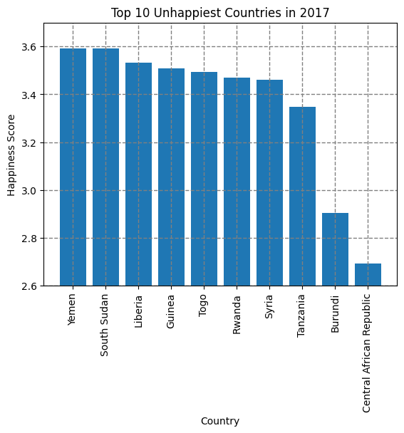

```python
x = list(top_10_2017.index)
y = top_10_2017['happiness_score']

plt.bar(x, y)
plt.grid(color='grey', linestyle='--', linewidth=1)
plt.xlabel('Country')
plt.xticks(rotation = 'vertical', fontsize=10)
plt.ylim(2.6, 3.7)
plt.ylabel('Happiness Score')
plt.title('Top 10 Unhappiest Countries in 2017')
plt.show()
```

```python
top_10_2018 = sub_data_2018.iloc[:,[1]][-10:]
top_10_2018
```

| country | happiness_score |
| --- | --- |
| Malawi | 3.587 |
| Haiti | 3.582 |
| Liberia | 3.495 |
| Syria | 3.462 |
| Rwanda | 3.408 |
| Yemen | 3.355 |
| Tanzania | 3.303 |
| South Sudan | 3.254 |
| Central African Republic | 3.083 |
| Burundi | 2.905 |

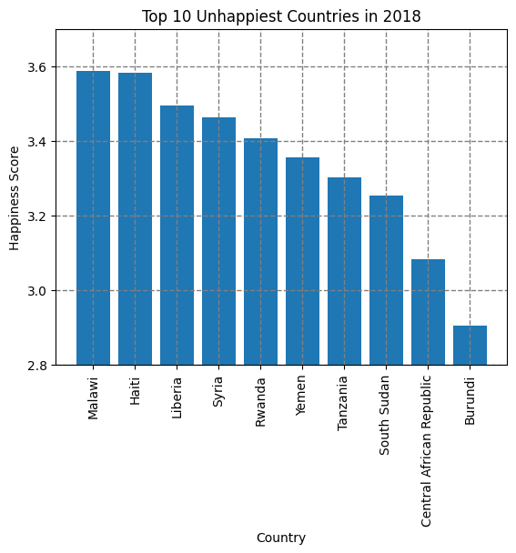

```python
x = list(top_10_2018.index)
y = top_10_2018['happiness_score']

plt.bar(x, y)
plt.grid(color='grey', linestyle='--', linewidth=1)
plt.xlabel('Country')
plt.xticks(rotation = 'vertical', fontsize=10)
plt.ylim(2.8, 3.7)
plt.ylabel('Happiness Score')
plt.title('Top 10 Unhappiest Countries in 2018')
plt.show()
```

```python
top_10_2019 = sub_data_2019.iloc[:,[1]][-10:]
top_10_2019
```

| country | happiness_score |
| --- | --- |
| Haiti | 3.597 |
| Botswana | 3.488 |
| Syria | 3.462 |
| Malawi | 3.410 |
| Yemen | 3.380 |
| Rwanda | 3.334 |
| Tanzania | 3.231 |
| Afghanistan | 3.203 |
| Central African Republic | 3.083 |
| South Sudan | 2.853 |

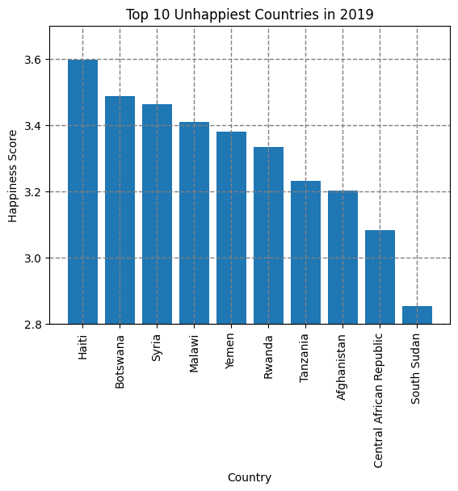

```python
x = list(top_10_2019.index)
y = top_10_2019['happiness_score']

plt.bar(x, y)
plt.grid(color='grey', linestyle='--', linewidth=1)
plt.xlabel('Country')
plt.xticks(rotation = 'vertical', fontsize=10)
plt.ylim(2.8, 3.7)
plt.ylabel('Happiness Score')
plt.title('Top 10 Unhappiest Countries in 2019')
plt.show()
```

### **4. Is there any correlation between happiness levels and Gross Domestic Product (GDP) per capita?**

By creating a scatter plot that includes `happiness_score` as x values and `economy` (GDP per capita) as y values, we can see if they have a correlation between happiness score and economy. To reduce the uncertainty, we will make this graph and see if we have same result throughout all of the years.

```python
happy_socore_econ = sub_data_2015.iloc[:,[1, 2]]
happy_socore_econ
```

| country | happiness_score | economy |
| --- | --- | --- |
| Switzerland | 7.587 | 1.39651 |
| Iceland | 7.561 | 1.30232 |
| Denmark | 7.527 | 1.32548 |
| Norway | 7.522 | 1.45900 |
| Canada | 7.427 | 1.32629 |
| ... | ... | ... |
| Rwanda | 3.465 | 0.22208 |
| Benin | 3.340 | 0.28665 |
| Syria | 3.006 | 0.66320 |
| Burundi | 2.905 | 0.01530 |
| Togo | 2.839 | 0.20868 |

158 rows × 2 columns

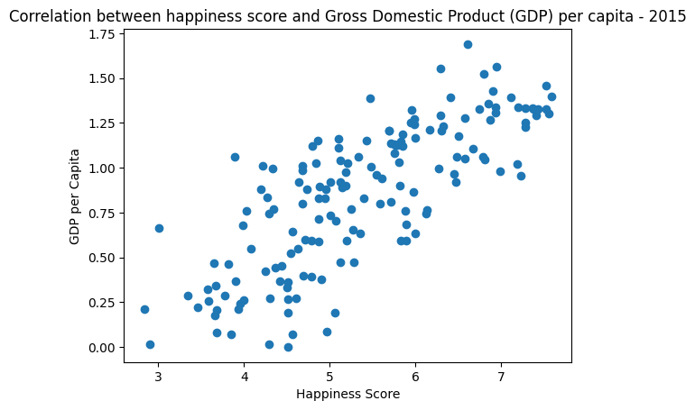

```python
x = happy_socore_econ['happiness_score']
y = happy_socore_econ['economy']

plt.scatter(x, y)
plt.xlabel('Happiness Score')
plt.ylabel('GDP per Capita')
plt.title('Correlation between happiness score and Gross Domestic Product (GDP) per capita - 2015')
plt.show()
```

```python
happy_socore_econ = sub_data_2016.iloc[:,[1, 2]]
happy_socore_econ
```

| country | happiness_score | economy |
| --- | --- | --- |
| Denmark | 7.526 | 1.44178 |
| Switzerland | 7.509 | 1.52733 |
| Iceland | 7.501 | 1.42666 |
| Norway | 7.498 | 1.57744 |
| Finland | 7.413 | 1.40598 |
| ... | ... | ... |
| Benin | 3.484 | 0.39499 |
| Afghanistan | 3.360 | 0.38227 |
| Togo | 3.303 | 0.28123 |
| Syria | 3.069 | 0.74719 |
| Burundi | 2.905 | 0.06831 |

157 rows × 2 columns

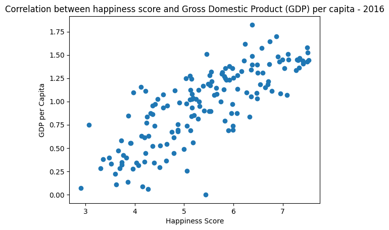

```python
x = happy_socore_econ['happiness_score']
y = happy_socore_econ['economy']

plt.scatter(x, y)
plt.xlabel('Happiness Score')
plt.ylabel('GDP per Capita')
plt.title('Correlation between happiness score and Gross Domestic Product (GDP) per capita - 2016')
plt.show()
```

```python
happy_socore_econ = sub_data_2017.iloc[:,[1, 2]]
happy_socore_econ
```

| country | happiness_score | economy |
| --- | --- | --- |
| Norway | 7.537 | 1.616463 |
| Denmark | 7.522 | 1.482383 |
| Iceland | 7.504 | 1.480633 |
| Switzerland | 7.494 | 1.564980 |
| Finland | 7.469 | 1.443572 |
| ... | ... | ... |
| Rwanda | 3.471 | 0.368746 |
| Syria | 3.462 | 0.777153 |
| Tanzania | 3.349 | 0.511136 |
| Burundi | 2.905 | 0.091623 |
| Central African Republic | 2.693 | 0.000000 |

155 rows × 2 columns

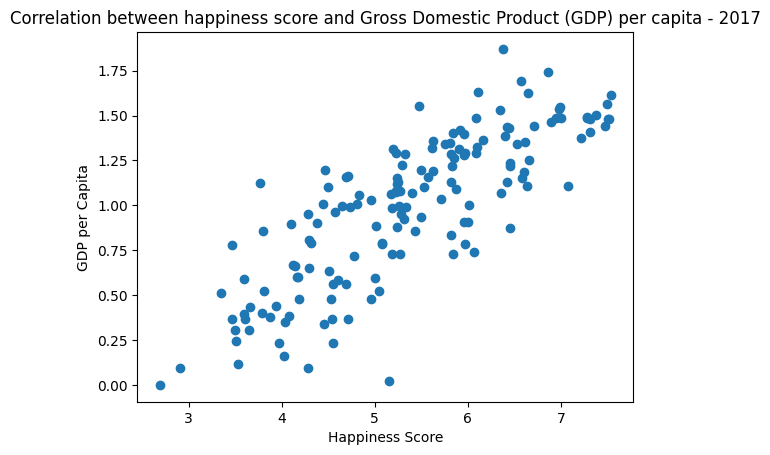

```python
x = happy_socore_econ['happiness_score']
y = happy_socore_econ['economy']

plt.scatter(x, y)
plt.xlabel('Happiness Score')
plt.ylabel('GDP per Capita')
plt.title('Correlation between happiness score and Gross Domestic Product (GDP) per capita - 2017')
plt.show()
```

```python
happy_socore_econ = sub_data_2018.iloc[:,[1, 2]]
happy_socore_econ
```

| country | happiness_score | economy |
| --- | --- | --- |
| Finland | 7.632 | 1.305 |
| Norway | 7.594 | 1.456 |
| Denmark | 7.555 | 1.351 |
| Iceland | 7.495 | 1.343 |
| Switzerland | 7.487 | 1.420 |
| ... | ... | ... |
| Yemen | 3.355 | 0.442 |
| Tanzania | 3.303 | 0.455 |
| South Sudan | 3.254 | 0.337 |
| Central African Republic | 3.083 | 0.024 |
| Burundi | 2.905 | 0.091 |

156 rows × 2 columns

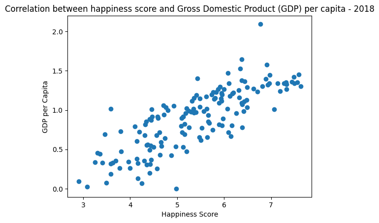

```python
x = happy_socore_econ['happiness_score']
y = happy_socore_econ['economy']

plt.scatter(x, y)
plt.xlabel('Happiness Score')
plt.ylabel('GDP per Capita')
plt.title('Correlation between happiness score and Gross Domestic Product (GDP) per capita - 2018')
plt.show()
```

```python
happy_socore_econ = sub_data_2019.iloc[:,[1, 2]]
happy_socore_econ
```

| country | happiness_score | economy |
| --- | --- | --- |
| Finland | 7.769 | 1.340 |
| Denmark | 7.600 | 1.383 |
| Norway | 7.554 | 1.488 |
| Iceland | 7.494 | 1.380 |
| Netherlands | 7.488 | 1.396 |
| ... | ... | ... |
| Rwanda | 3.334 | 0.359 |
| Tanzania | 3.231 | 0.476 |
| Afghanistan | 3.203 | 0.350 |
| Central African Republic | 3.083 | 0.026 |
| South Sudan | 2.853 | 0.306 |

156 rows × 2 columns

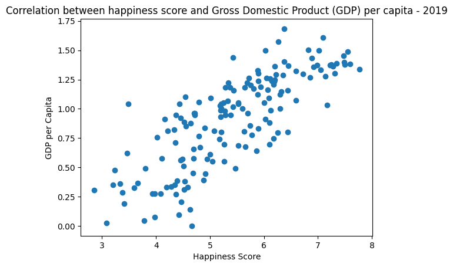

```python
x = happy_socore_econ['happiness_score']
y = happy_socore_econ['economy']

plt.scatter(x, y)
plt.xlabel('Happiness Score')
plt.ylabel('GDP per Capita')
plt.title('Correlation between happiness score and Gross Domestic Product (GDP) per capita - 2019')
plt.show()
```

### **5. Is there any correlation between happiness levels and life expectancy?**

```python
happy_socore_life_expectancy = sub_data_2015.iloc[:,[1, 4]]
happy_socore_life_expectancy
```

| country | happiness_score | life_expectancy |
| --- | --- | --- |
| Switzerland | 7.587 | 0.94143 |
| Iceland | 7.561 | 0.94784 |
| Denmark | 7.527 | 0.87464 |
| Norway | 7.522 | 0.88521 |
| Canada | 7.427 | 0.90563 |
| ... | ... | ... |
| Rwanda | 3.465 | 0.42864 |
| Benin | 3.340 | 0.31910 |
| Syria | 3.006 | 0.72193 |
| Burundi | 2.905 | 0.22396 |
| Togo | 2.839 | 0.28443 |

158 rows × 2 columns

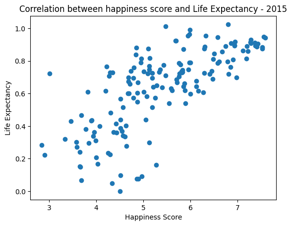

```python
x = happy_socore_life_expectancy['happiness_score']
y = happy_socore_life_expectancy['life_expectancy']

plt.scatter(x, y)
plt.xlabel('Happiness Score')
plt.ylabel('Life Expectancy')
plt.title('Correlation between happiness score and Life Expectancy - 2015')
plt.show()
```

```python
happy_socore_life_expectancy = sub_data_2016.iloc[:,[1, 4]]
happy_socore_life_expectancy
```

| country | happiness_score | life_expectancy |
| --- | --- | --- |
| Denmark | 7.526 | 0.79504 |
| Switzerland | 7.509 | 0.86303 |
| Iceland | 7.501 | 0.86733 |
| Norway | 7.498 | 0.79579 |
| Finland | 7.413 | 0.81091 |
| ... | ... | ... |
| Benin | 3.484 | 0.21028 |
| Afghanistan | 3.360 | 0.17344 |
| Togo | 3.303 | 0.24811 |
| Syria | 3.069 | 0.62994 |
| Burundi | 2.905 | 0.15747 |

157 rows × 2 columns

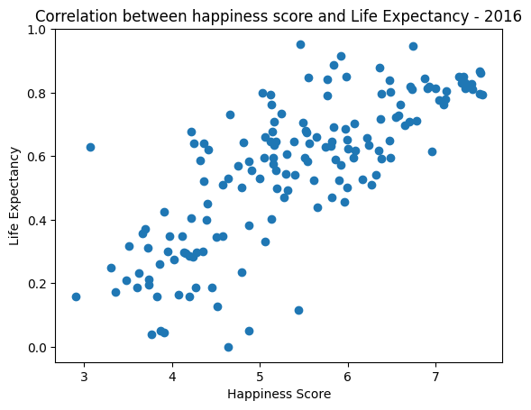

```python
x = happy_socore_life_expectancy['happiness_score']
y = happy_socore_life_expectancy['life_expectancy']

plt.scatter(x, y)
plt.xlabel('Happiness Score')
plt.ylabel('Life Expectancy')
plt.title('Correlation between happiness score and Life Expectancy - 2016')
plt.show()
```

```python
happy_socore_life_expectancy = sub_data_2017.iloc[:,[1, 4]]
happy_socore_life_expectancy
```

| country | happiness_score | life_expectancy |
| --- | --- | --- |
| Norway | 7.537 | 0.796667 |
| Denmark | 7.522 | 0.792566 |
| Iceland | 7.504 | 0.833552 |
| Switzerland | 7.494 | 0.858131 |
| Finland | 7.469 | 0.809158 |
| ... | ... | ... |
| Rwanda | 3.471 | 0.326425 |
| Syria | 3.462 | 0.500533 |
| Tanzania | 3.349 | 0.364509 |
| Burundi | 2.905 | 0.151611 |
| Central African Republic | 2.693 | 0.018773 |

155 rows × 2 columns

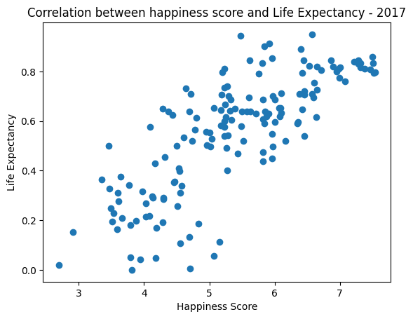

```python
x = happy_socore_life_expectancy['happiness_score']
y = happy_socore_life_expectancy['life_expectancy']

plt.scatter(x, y)
plt.xlabel('Happiness Score')
plt.ylabel('Life Expectancy')
plt.title('Correlation between happiness score and Life Expectancy - 2017')
plt.show()
```

```python
happy_socore_life_expectancy = sub_data_2018.iloc[:,[1, 4]]
happy_socore_life_expectancy
```

| country | happiness_score | life_expectancy |
| --- | --- | --- |
| Finland | 7.632 | 0.874 |
| Norway | 7.594 | 0.861 |
| Denmark | 7.555 | 0.868 |
| Iceland | 7.495 | 0.914 |
| Switzerland | 7.487 | 0.927 |
| ... | ... | ... |
| Yemen | 3.355 | 0.343 |
| Tanzania | 3.303 | 0.381 |
| South Sudan | 3.254 | 0.177 |
| Central African Republic | 3.083 | 0.010 |
| Burundi | 2.905 | 0.145 |

156 rows × 2 columns

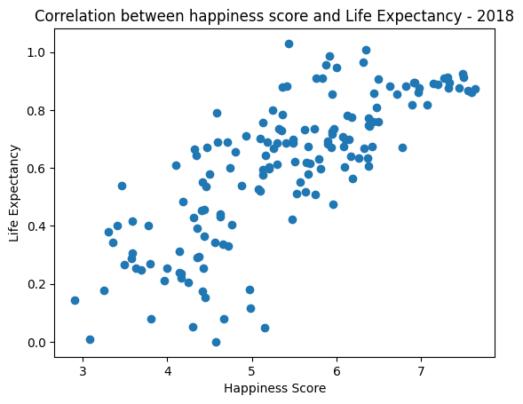

```python
x = happy_socore_life_expectancy['happiness_score']
y = happy_socore_life_expectancy['life_expectancy']

plt.scatter(x, y)
plt.xlabel('Happiness Score')
plt.ylabel('Life Expectancy')
plt.title('Correlation between happiness score and Life Expectancy - 2018')
plt.show()
```

```python
happy_socore_life_expectancy = sub_data_2019.iloc[:,[1, 4]]
happy_socore_life_expectancy
```

| country | happiness_score | life_expectancy |
| --- | --- | --- |
| Finland | 7.769 | 0.986 |
| Denmark | 7.600 | 0.996 |
| Norway | 7.554 | 1.028 |
| Iceland | 7.494 | 1.026 |
| Netherlands | 7.488 | 0.999 |
| ... | ... | ... |
| Rwanda | 3.334 | 0.614 |
| Tanzania | 3.231 | 0.499 |
| Afghanistan | 3.203 | 0.361 |
| Central African Republic | 3.083 | 0.105 |
| South Sudan | 2.853 | 0.295 |

156 rows × 2 columns

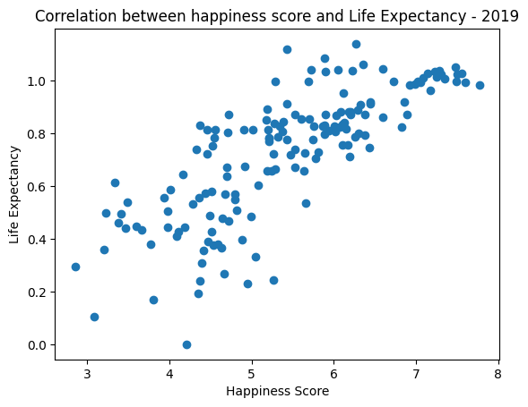

```python
x = happy_socore_life_expectancy['happiness_score']
y = happy_socore_life_expectancy['life_expectancy']

plt.scatter(x, y)
plt.xlabel('Happiness Score')
plt.ylabel('Life Expectancy')
plt.title('Correlation between happiness score and Life Expectancy - 2019')
plt.show()
```

## **6. Which factors have the strongest impact on happiness across different countries?**

To see which factors impacts the happiness across different countries, we can create correlation matrix that includes all of the factors. Correlation matrix is a statistical technique used to evaluate the relationship between two variables in a dataset, so it will be good for us to compare between the variables. Also, to reduce the uncertainty here too, we will make 5 of the correlation matrix here too.

```
<function matplotlib.pyplot.show(close=None, block=None)>
```

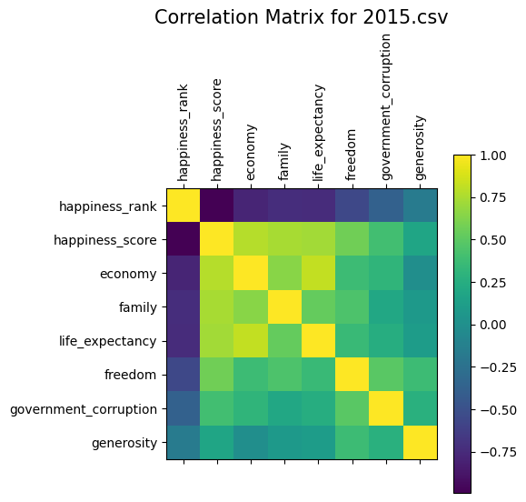

```python
corr = sub_data_2015.corr()
mat = plt.matshow(corr)
plt.xticks(range(len(corr.columns)), corr.columns, rotation=90)
plt.yticks(range(len(corr.columns)), corr.columns)
plt.colorbar(mat)
plt.title('Correlation Matrix for 2015.csv', fontsize=15)
plt.show
```

```
<function matplotlib.pyplot.show(close=None, block=None)>
```

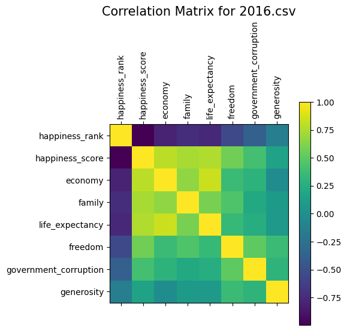

```python
corr = sub_data_2016.corr()
mat = plt.matshow(corr)
plt.xticks(range(len(corr.columns)), corr.columns, rotation=90)
plt.yticks(range(len(corr.columns)), corr.columns)
plt.colorbar(mat)
plt.title('Correlation Matrix for 2016.csv', fontsize=15)
plt.show
```

```
<function matplotlib.pyplot.show(close=None, block=None)>
```

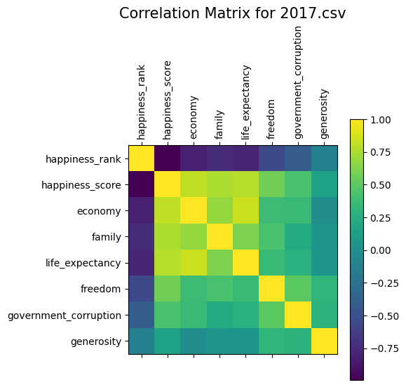

```python
corr = sub_data_2017.corr()
mat = plt.matshow(corr)
plt.xticks(range(len(corr.columns)), corr.columns, rotation=90)
plt.yticks(range(len(corr.columns)), corr.columns)
plt.colorbar(mat)
plt.title('Correlation Matrix for 2017.csv', fontsize=15)
plt.show
```

```
<function matplotlib.pyplot.show(close=None, block=None)>
```

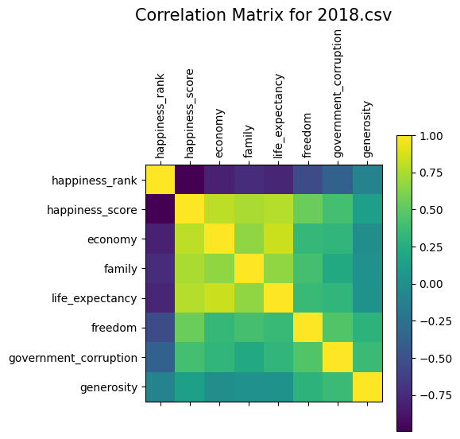

```python
corr = sub_data_2018.corr()
mat = plt.matshow(corr)
plt.xticks(range(len(corr.columns)), corr.columns, rotation=90)
plt.yticks(range(len(corr.columns)), corr.columns)
plt.colorbar(mat)
plt.title('Correlation Matrix for 2018.csv', fontsize=15)
plt.show
```

```
<function matplotlib.pyplot.show(close=None, block=None)>
```

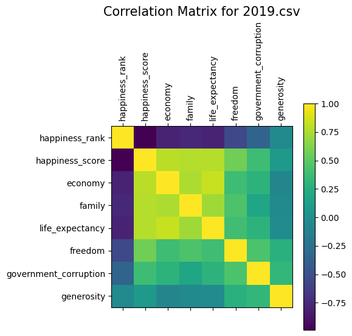

```python
corr = sub_data_2019.corr()
mat = plt.matshow(corr)
plt.xticks(range(len(corr.columns)), corr.columns, rotation=90)
plt.yticks(range(len(corr.columns)), corr.columns)
plt.colorbar(mat)
plt.title('Correlation Matrix for 2019.csv', fontsize=15)
plt.show
```